# Midterm

Farzana Naoshin

2021-02-12

```r
library(ggplot2)
library(readxl)
library(vembedr)
library(visdat)
library(tidyverse)
library(skimr)
library(palmerpenguins)
library(dplyr)
library(ggthemes)
library(ggridges)
library(janitor)
library(wesanderson)
library(here)
```

## **Research Question** (10 points)

#### **Define your research question below. What about the data interests you? What is a specific question you want to find out about the data?**

#### I will be working on the friends datasets from the provided webside. I am a fan of this series and excited to work on a dataset about the characters’ emotions. The specific research question that I want to answer is “Which of the main six characters in friends series showed the most drastic change in few emotional responses from season one through four?” Since it is a comedy series (or I consider it so), I wanted to see the number of joyful and sad scenes especially and who play them the most over the seasons. Unfortunately, emotion data is only available till season 4 in my downloaded files, so I will be using only season 1, 2 3, and 4.

#### **Given your question, what is your expectation about the data?**

#### I think Chandler would play the most joyful scenes, Ross the sad ones, Rachel would play more mad scenes and Monica would play the powerful scenes.

## **Data Loading** (10 points)

#### **Load the data below and use `dplyr::glimpse()` or `skimr::skim()` on the data. You should upload the data file into the `data` directory.**

```r
# Using read_excel here because this is what I am learning in this class, it is new to me. I always converted xlsx into csv and and loaded csv data.

friends = read_excel(here('data/friends_excel.xlsx'),
                      sheet=1,
                      na="NA")
friendsEMO = read_excel(here('data/friends_emotions_excel.xlsx'),
                      sheet=1,
                      na="NA")

# Direct links from the provided website
#friends = readr::read_csv('https://raw.githubusercontent.com/rfordatascience/tidytuesday/master/data/2020/2020-09-08/friends.csv')
#friends_emotions = readr::read_csv('https://raw.githubusercontent.com/rfordatascience/tidytuesday/master/data/2020/2020-09-08/friends_emotions.csv')

#friendsCSV = read.csv("friends.csv")
#friendsEmoCSV = read.csv("friends_emotions.csv")
```

```r
# text and speaker are character variables and season, episode, scene and utterance are numeric variable.
dplyr::glimpse(friends)
```

```
## Rows: 67,373
## Columns: 6
## $ text      <chr> "There's nothing to tell! He's just some guy I work with!",…
## $ speaker   <chr> "Monica Geller", "Joey Tribbiani", "Chandler Bing", "Phoebe…
## $ season    <dbl> 1, 1, 1, 1, 1, 1, 1, 1, 1, 1, 1, 1, 1, 1, 1, 1, 1, 1, 1, 1,…
## $ episode   <dbl> 1, 1, 1, 1, 1, 1, 1, 1, 1, 1, 1, 1, 1, 1, 1, 1, 1, 1, 1, 1,…
## $ scene     <dbl> 1, 1, 1, 1, 1, 1, 1, 1, 1, 1, 1, 1, 1, 1, 1, 1, 1, 1, 1, 1,…
## $ utterance <dbl> 1, 2, 3, 4, 5, 6, 7, 8, 9, 10, 11, 12, 13, 14, 15, 16, 17, …
```

```r
skimr::skim(friendsEMO)
```

Data summary

| Name | friendsEMO |
| --- | --- |
| Number of rows | 12606 |
| Number of columns | 5 |
| _______________________ |  |
| Column type frequency: |  |
| character | 1 |
| numeric | 4 |
| ________________________ |  |
| Group variables | None |

**Variable type: character**

| skim_variable | n_missing | complete_rate | min | max | empty | n_unique | whitespace |
| --- | --- | --- | --- | --- | --- | --- | --- |
| emotion | 0 | 1 | 3 | 8 | 0 | 7 | 0 |

**Variable type: numeric**

| skim_variable | n_missing | complete_rate | mean | sd | p0 | p25 | p50 | p75 | p100 | hist |
| --- | --- | --- | --- | --- | --- | --- | --- | --- | --- | --- |
| season | 0 | 1 | 2.57 | 1.11 | 1 | 2 | 3 | 4 | 4 | ▆▆▁▇▇ |
| episode | 0 | 1 | 13.19 | 7.20 | 1 | 7 | 14 | 20 | 25 | ▇▆▇▇▇ |
| scene | 0 | 1 | 7.52 | 4.43 | 1 | 4 | 7 | 11 | 29 | ▇▇▂▁▁ |
| utterance | 0 | 1 | 9.80 | 5.94 | 1 | 5 | 9 | 14 | 30 | ▇▇▅▂▁ |

```r
slice(friendsEMO)
```

```
## # A tibble: 12,606 x 5
##    season episode scene utterance emotion
##     <dbl>   <dbl> <dbl>     <dbl> <chr>
##  1      1       1     4         1 Mad
##  2      1       1     4         3 Neutral
##  3      1       1     4         4 Joyful
##  4      1       1     4         5 Neutral
##  5      1       1     4         6 Neutral
##  6      1       1     4         7 Neutral
##  7      1       1     4         8 Scared
##  8      1       1     4        10 Joyful
##  9      1       1     4        11 Joyful
## 10      1       1     4        12 Sad
## # … with 12,596 more rows
```

#### **If there are any quirks that you have to deal with `NA` coded as something else, or it is multiple tables, please make some notes here about what you need to do before you start transforming the data in the next section.**

#### I converted the CSV files to excel, and assigned missing values as “NA”. I want the emotions with character names in a single data frame; hence I will be merging the two datasets using left_join.

#### **Make sure your data types are correct!**

## **Data Transforming** (15 points)

#### **If the data needs to be transformed in any way (values recoded, pivoted, etc), do it here. Examples include transforming a continuous variable into a categorical using `case_when()`, etc.**

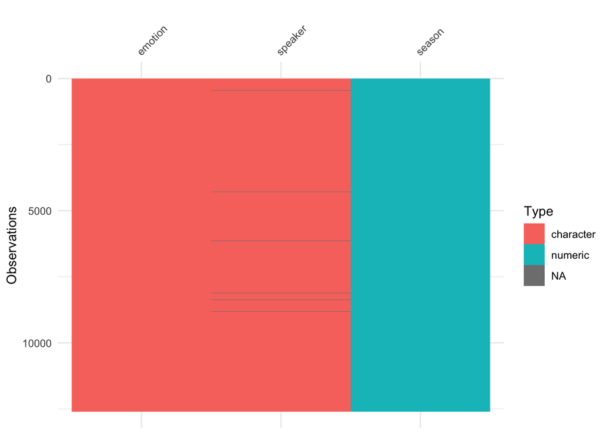

```r
# I dont need to transform values but need to merge the two main dataset because one has the emotional responses and the other has the character names.
friendsMERGE = friendsEMO %>%
  left_join(y = friends,
             by = c("season" = "season", "episode" = "episode",
                    "scene" = "scene", "utterance" = "utterance"))
#nrow(friendsMERGE)
#friendsMERGEinner = friendsEMO %>%
#  inner_join(y = friends,
#             by = c("season" = "season", "episode" = "episode",
#                    "scene" = "scene", "utterance" = "utterance"))
#nrow(friendsMERGEinner)

friendsMERGE = friendsMERGE %>%
  select(season, emotion, speaker)

#!is.na(friendsMERGE) too many rows to check
vis_dat(friendsMERGE)
```

#### **Bonus points (5 points) for datasets that require merging of tables, but only if you reason through whether you should use `left_join`, `inner_join`, or `right_join` on these tables. No credit will be provided if you don’t.**

#### Left_join adds columns to the right even if they do not have values in few rows for the conditions I am joining them. Inner_join returns rows when both merging tables have maching values.I am using left_join here because to me it is more intuitive (I have a table I like I want to add columns in that table). However, I did test inner_join and it does not give a different row numbers, and also I want the emotional responses for the rows with character names and no emotional response value would have been no use for this project.

#### **Show your transformed table here. Use tools such as `glimpse()`, `skim()` or `head()` to illustrate your point.**

```r
slice(friendsMERGE)
```

```
## # A tibble: 12,606 x 3
##    season emotion speaker
##     <dbl> <chr>   <chr>
##  1      1 Mad     Ross Geller
##  2      1 Neutral Joey Tribbiani
##  3      1 Joyful  Chandler Bing
##  4      1 Neutral Joey Tribbiani
##  5      1 Neutral Chandler Bing
##  6      1 Neutral Joey Tribbiani
##  7      1 Scared  Chandler Bing
##  8      1 Joyful  Joey Tribbiani
##  9      1 Joyful  Chandler Bing
## 10      1 Sad     Ross Geller
## # … with 12,596 more rows
```

## **Visualizing and Summarizing** (15 points)

#### **Use `group_by()/summarize()` to make a summary of the data here. The summary should be relevant to your research question**

```r
# Here I am filtering the the emotions I need and for the main six characters. We have emotions data only for four seasons.
friendsFinal = friendsMERGE %>%
    filter(emotion %in% c("Joyful", "Sad", "Powerful", "Mad")) %>%
    filter(speaker %in% c("Chandler Bing", "Joey Tribbiani",
           "Ross Geller", "Phoebe Buffay", "Monica Geller",
           "Rachel Green")) %>%
    filter(season %in% c(1, 2, 3, 4)) %>%
    group_by(speaker, emotion, season) %>%
    summarize(EmoCount = n())
glimpse(friendsFinal)
```

```
## Rows: 96
## Columns: 4
## Groups: speaker, emotion [24]
## $ speaker  <chr> "Chandler Bing", "Chandler Bing", "Chandler Bing", "Chandler…
## $ emotion  <chr> "Joyful", "Joyful", "Joyful", "Joyful", "Mad", "Mad", "Mad",…
## $ season   <dbl> 1, 2, 3, 4, 1, 2, 3, 4, 1, 2, 3, 4, 1, 2, 3, 4, 1, 2, 3, 4, …
## $ EmoCount <int> 96, 92, 103, 96, 57, 57, 63, 41, 20, 17, 39, 65, 17, 18, 18,…
```

```r
slice(friendsFinal)
```

```
## # A tibble: 96 x 4
## # Groups:   speaker, emotion [24]
##    speaker       emotion  season EmoCount
##    <chr>         <chr>     <dbl>    <int>
##  1 Chandler Bing Joyful        1       96
##  2 Chandler Bing Joyful        2       92
##  3 Chandler Bing Joyful        3      103
##  4 Chandler Bing Joyful        4       96
##  5 Chandler Bing Mad           1       57
##  6 Chandler Bing Mad           2       57
##  7 Chandler Bing Mad           3       63
##  8 Chandler Bing Mad           4       41
##  9 Chandler Bing Powerful      1       20
## 10 Chandler Bing Powerful      2       17
## # … with 86 more rows
```

#### **What are your findings about the summary? Are they what you expected?**

#### The summary successfully filtered out first four seasons and few emotions that I will be looking at. This table is exactly what I needed for further analysis.

#### **Make at least two plots that help you answer your question on the transformed or summarized data.**

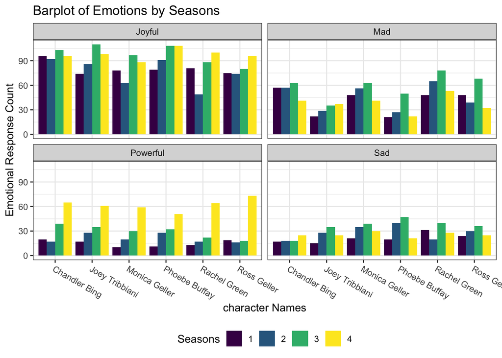

```r
# Bar plot by each four interested emotions
ggplot(data = friendsFinal,
       aes(x = speaker,
           y = EmoCount,
           fill = factor(season))) +
    geom_bar(stat = "identity", position = "dodge") +
    facet_wrap(vars(emotion)) +
    scale_fill_discrete(name = "Seasons") +
    labs(x = "character Names",
       y = "Emotional Response Count",
       title = "Barplot of Emotions by Seasons") +
    theme_bw() +
    theme(axis.text.x = element_text(angle = -30, hjust = 0),
          legend.position = "bottom") +
    scale_fill_viridis_d(name = "Seasons") +
    scale_color_manual(values = wes_palette("BottleRocket2"))
```

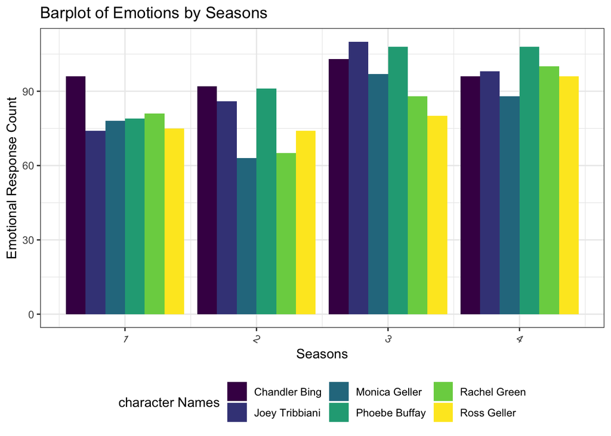

```r
# Bar plot for all emotional response by season
ggplot(data = friendsFinal,
       aes(x = season,
           y = EmoCount,
           fill = factor(speaker))) +
    geom_bar(stat = "identity", position = "dodge") +
    scale_fill_discrete(name = "Seasons") +
    labs(x = "Seasons",
       y = "Emotional Response Count",
       title = "Barplot of Emotions by Seasons") +
    theme_bw() +
    theme(axis.text.x = element_text(angle = -30, hjust = 0),
          legend.position = "bottom") +
    scale_fill_viridis_d(name = "character Names") +
    scale_color_manual(values = wes_palette("BottleRocket1"))
```

## **Final Summary** (10 points)

#### **Functions**

```r
# I followed the class notes and this website to write the functions https://www.statmethods.net/management/userfunctions.html

gubla = function(df, emo, seas){
  outDF  = df %>%
    filter(emotion %in% c(emo)) %>%
    filter(season == seas) %>%
    filter(speaker %in% c("Chandler Bing", "Joey Tribbiani",
           "Ross Geller", "Phoebe Buffay", "Monica Geller",
           "Rachel Green")) # I only want the main six characters' emotional responses
  return(outDF)
}

pipra = function(df, emo){
  outDF  = df %>%
    group_by(speaker) %>%
    summarize(emo = n())
  return(outDF)
}

# This is how I planned to use them
#JoyS1 = gubla(df = friendsMERGE, emo = "Joyful", seas = 1)
#SadS1 = gubla(df = friendsMERGE, emo = "Sad", seas = 1)
#JoyS1summary = pipra(df = JoyS1)
#SadS1summary = pipra(df = SadS1)
#MERGEemoS1 = JoyS1summary%>%
#  left_join(y = SadS1summary,
#             by = c("speaker" = "speaker"))
#slice(MERGEemoS1)
```